# Manipulação e Persistência de Grandes Quantidades de Dados em Python

*por Iuri Sônego Cardoso.*

Trabalhar com grandes quantidade de dados envolve o uso de vetores (ou uma estrutura equivalente, como veremos) e tipos de dados compostos (também conhecidos como *registros*). Esta manipulação ocorre em memória, podendo também ocorrem em arquivos, sejam estes binários ou de texto. Este útlimo envolve a manipulação e operação de strings.

## 1 Vetores em Python

Diferentemente de outras linguagens de programação, Python não possui nativamente uma estrutura para trabalhar com vetores (arranjos ou matrizes) de forma primitiva. Em vez disto, é possível utilizar a estrutura de dados primitiva de Lista como vetores de uma, duas ou mais dimensões. Também é possível utilizar módulos (bibliotecas) como `array`, `numpy`, `pandas`, `scipy`, `tensorflow`, `pytorch` e outros. Cada uma destas formas possui vantagens e desvantagens com relação à garantia da homogeneidade dos dados, performance na execução de operações, consumo de memória, abstração de operações e facilidades de uso.

Iremos utilizar aqui a estrutura de dados de Lista, por esta ser primitiva em Python. Um vetor de uma dimensão é qualquer lista de valores separados por vírgulas dentro colchetes (`[ ]`)

```python
vetor = [10, 15, 100, -1, 0, 20]

print("Dados do vetor:", vetor)
print("Elemento da posição 0:", vetor[0])
print("Elemento da posição 1:", vetor[1])
print("Tamanho do vetor:", len(vetor), "elementos")

vetor[0] = -100 # alteração do valor da posição 0.
print("\nElemento da posição 0 alterado para:", vetor[0])
print("Dados do vetor:", vetor)
```

```
Dados do vetor: [10, 15, 100, -1, 0, 20]
Elemento da posição 0: 10
Elemento da posição 1: 15
Tamanho do vetor: 6 elementos

Elemento da posição 0 alterado para: -100
Dados do vetor: [-100, 15, 100, -1, 0, 20]
```

Utilizando Listas, é possível representar vetores de 2 ou mais dimensões utilizando Listas como elementos para Listas. Exemplificando: em um vetor de 2 dimensões de inteiros, cada elemento da primeira Lista (a "mais externa") é uma outra Lista (uma "lista interna"), sendo que cada elemento desta outra Lista é um valor inteiro armazenado.

Segue um código de exemplo:

```python
# um vetor de 2 dimensões de tamanho 3 x 2 = 6 elementos.
vetor2D = [ [10, 20] , [30, 40] , [50, 60] ]
print("Vetor 2D:", vetor2D)

print("\nlinha 0:", vetor2D[0])
print("linha 1:", vetor2D[1])
print("linha 2:", vetor2D[2])

print("\nlinha 0, coluna 0:", vetor2D[0][0])

vetor2D[0] = [70 , 80]
print("\nlinha 0 foi alterada:", vetor2D[0])
print("vetor:", vetor2D)

print("\nlinha 0:", vetor2D[0])
print("linha 1:", vetor2D[1])
print("linha 2:", vetor2D[2])

# É possível trocar uma linha por um valor (de qualquer tipo) ou até uma lista com mais de 2 valores
vetor2D[0] = 100
vetor2D[1] = [200, 300, 400]
print("\nvetor:", vetor2D)
print("linha 0:", vetor2D[0])
print("linha 1:", vetor2D[1])
print("linha 2:", vetor2D[2])
```

```
Vetor 2D: [[10, 20], [30, 40], [50, 60]]

linha 0: [10, 20]
linha 1: [30, 40]
linha 2: [50, 60]

linha 0, coluna 0: 10

linha 0 foi alterada: [70, 80]
vetor: [[70, 80], [30, 40], [50, 60]]

linha 0: [70, 80]
linha 1: [30, 40]
linha 2: [50, 60]

vetor: [100, [200, 300, 400], [50, 60]]
linha 0: 100
linha 1: [200, 300, 400]
linha 2: [50, 60]
```

Diferentemente de outras linguagens, as Listas em Python permitem armazenar dados de diferentes tipos. E assim como as variáveis escalares (variáveis que armazenam um único valor), Listas permitem trocar o tipo de dado armazenado em determinada posição, conforme exemplo:

```python
vetor = [ 10 , 20.5 , "Programação"]
print("vetor:", vetor)

vetor[0] = [5 , 10]
print("\nvetor[0] alterado para: ", vetor[0])
print("vetor:", vetor)
```

```
vetor: [10, 20.5, 'Programação']

vetor[0] alterado para:  [5, 10]
vetor: [[5, 10], 20.5, 'Programação']
```

### 1.1 Iterando Vetores

Iterar um vetor significa percorrer os elementos dele, um a um. Isto pode ser feito em Python de duas formas:

1. usando próprio o vetor como conjunto de elementos a ser iterado pela estrutura de repetição `for`;
2. criar uma estrutura de dados iterável que possua os índices do vetor a serem acessados e passar esta estrutura para ser iterada pela estrutura de repetição `for`.

A primeira forma é a mais simples e, por isso, desejável em Python, enquanto a segunda forma pode ser útil em situações em que a estrutura de repetição deva conhecer o índice do elemento dentro do vetor. Nesse último caso, utilize a função `len()` para obter o tamanho do vetor.

Segue exemplo utilizando o vetor como iterável para a estrutura `for`:

```python
# usando próprio o vetor como conjunto de elementos a ser iterado pela estrutura de repetição for

vetor = [ "banana" , "maçã" , "laranja" , "melancia" ]
for e in vetor:
  print(e , end=" ")
```

```
banana maçã laranja melancia
```

Segue exemplo utilizando estrutura de dados iterável com os índices do vetor:

```python
# usando uma estrutura de dados iterável que possua os índices do vetor a serem acessados e passar esta estrutura para ser iterada pela estrutura de repetição for.
vetor = [ "banana" , "maçã" , "laranja" , "melancia" ]
# gera faixa (range) de índices para o vetor.
indices = range(len(vetor))

print("Imprimindos elementos do vetor:", indices)
for i in indices:
  print("vetor[", i, "]: ", vetor[i], sep="")
```

```
Imprimindos elementos do vetor: range(0, 4)
vetor[0]: banana
vetor[1]: maçã
vetor[2]: laranja
vetor[3]: melancia
```

```python
# Iterando um vetor de 2 dimensões
vetor = [
  [ 1 , 2 ] ,
  [ 3 , 4 ] ,
  [ 5 , 6 ]
]

print("Iterando vetor:")
for linha in vetor:
  for e in linha:
    print(e, end=" ")
  print() # quebra de linha

print("\nIterando índices do vetor:")
for linha in range(len(vetor)):
  for coluna in range(len(vetor[linha])):
    print(f"[{linha}][{coluna}]:",vetor[linha][coluna], end=" ")
  print() # quebra de linha
```

```
Iterando vetor:
1 2
3 4
5 6

Iterando índices do vetor:
[0][0]: 1 [0][1]: 2
[1][0]: 3 [1][1]: 4
[2][0]: 5 [2][1]: 6
```

```python
# Iterando um vetor de 3 dimensões
vetor = [
  [
    [  1 ,  2 ] ,
    [  3 ,  4 ] ,
    [  5 ,  6 ]
  ] ,
  [
    [  7 ,  8 ] ,
    [  9 , 10 ] ,
    [ 11 , 12 ]
  ]
]

for linha in vetor:
  for coluna in linha:
    for e in coluna:
      print(e, end=" ")
    print() # quebra de linha
  print() # quebra de linha
```

```
1 2
3 4
5 6

7 8
9 10
11 12
```

### 1.2 Passagem de Vetores por Parâmetro

Assim como em C, vetores em Python (listas) são passados automaticamente por referência para funções. Caso um valor seja modificado dentro da função, este será refletido fora dela, conforme exemplificado abaixo:

```python
def zerar(vet):
  tam = len(vet)
  for i in range(tam):
    vet[i] = 0

# PROGRAMA PRINCIPAL
vetor = [10, 20, 30, 40, 50, 60]

print("vetor =", vetor)

print("Zerando vetor...")
zerar(vetor)
print("vetor =", vetor)
```

```
vetor = [10, 20, 30, 40, 50, 60]
Zerando vetor...
vetor = [0, 0, 0, 0, 0, 0]
```

Na realidade, todo vetor é uma referência mesmo quando trabalhando com atribuição de uma variável para outra, conforme exemplo abaixo:

```python
vetor1 = [10 , 20 , 30 , 40 , 50]
vetor2 = vetor1

print("vetor1 =", vetor1)
print("vetor2 =", vetor2)

vetor2[0] = 60
print("Modificando vetor1[0] =", vetor2[0])
print("vetor1 =", vetor1)
print("vetor2 =", vetor2)
print("Observe que a alteração em vetor2 alterou também vetor1.\nAmbos são duas referências para o mesmo vetor.")
```

```
vetor1 = [10, 20, 30, 40, 50]
vetor2 = [10, 20, 30, 40, 50]
Modificando vetor1[0] = 60
vetor1 = [60, 20, 30, 40, 50]
vetor2 = [60, 20, 30, 40, 50]
Observe que a alteração em vetor2 alterou também vetor1.
Ambos são duas referências para o mesmo vetor.
```

### 1.3 Inicializando Vetores Automaticamente

Vimos que para inicializar vetores, basta posicionar os valores entre colchetes. Entretanto, se tivermos vetores muito grandes e precisamos preencher com valores triviais como zeros, por exemplo, temos uma tarefa trabalhosa e que pode gerar erros (contagem errada).

Para facilitar a inicialização de vetores com valores triviais (ou calculados, conforme adiante), pode-se utilizar o *for inline* conforme abaixo:

```python
# inicializa um vetor de 1 dimensão com 10 valores zero.
vetor = [ 0 for i in range(10) ]
# iniciaza um vetor de 2 dimensões com formato 3x3.
vetor2d = [ [ 0 for j in range(3) ] for i in range(3) ]
# iniciaza um vetor de 2 dimensões com formato 3x3.
vetor3d = [ [ [k + j*10 + i*100 for k in range(3) ] for j in range(3) ] for i in range(3) ]


print(vetor)
print(vetor2d)
print(vetor3d)
```

```
[0, 0, 0, 0, 0, 0, 0, 0, 0, 0]
[[0, 0, 0], [0, 0, 0], [0, 0, 0]]
[[[0, 1, 2], [10, 11, 12], [20, 21, 22]], [[100, 101, 102], [110, 111, 112], [120, 121, 122]], [[200, 201, 202], [210, 211, 212], [220, 221, 222]]]
```

A sintaxe para gerar um vetor (uma lista, para ser exato) com os elementos triviais ou calculados por meio de expressões, utilize a seguinte sintaxe:

`[ expressão for var in range ]`

Em que:

- `expressão` é uma expressão computacional que irá resultar no elemento a ser adicionado a cada iteração da estrutura `for`.
- `var` é uma variável que irá receber o elemento da estrutura de dados passada em `range`.
- `range` é a lista de valores a ser utilizada para iteração do `for`.

A `expressão` pode envolver a chamada de uma função ou até mesmo um *if inline*, conforme exemplo a seguir:

```python
linhas = 5
colunas = 5
# gerando uma matriz identidade: sempre que i e j forem iguais, significa que a posição faz parte da diagonal principal da matriz.
vetor = [ [ 1 if i==j else 0 for j in range(colunas) ] for i in range(linhas) ]

# imprimindo a matriz
for linha in vetor:
  for e in linha:
    print(e, end=" ")
  print() # quebra de linha
```

```
1 0 0 0 0
0 1 0 0 0
0 0 1 0 0
0 0 0 1 0
0 0 0 0 1
```

## 2 Tipos de Dados Compostos (Registros) em Python

A Linguagem Python não possui suporte a declaração de registros (`struct` em Linguagem C), porém possui suporte à Programação Orientada a Objetos, e com esta, classes que podem ser usados com o mesmo propósito. Não abordaremos Programação Orientada a Objetos, porém utilizaremos classes para emular `struct`'s, conforme exemplo abaixo:

```python
# estrutura que define uma pessoa.
class Pessoa:
  nome = ""           # campo é uma string e inicializa vazia
  idade = 0           # campo é um int e inicializa com zero.
  altura = 0.0        # campo é um float e inicializa com 0.0
  sexo = ""           # campo é uma string e inicializa vazia

# Cria uma variável do tipo Pessoa.
p = Pessoa()

# Imprime os dados da pessoa.
print("\nDados da pessoa ainda não preenchidos:")
print("Nome:", p.nome)
print("Idade:", p.idade)
print("Altura:", p.altura)
print("Sexo:", p.sexo)

# Atribui novos dados para a pessoa.
print("\nDados da pessoa preenchidos:")
p.nome = "Fulano de Tal"
p.idade = 23
p.altura = 1.75
p.sexo = "M"

# Imprime os novos dados da pessoa.
print("Nome:", p.nome)
print("Idade:", p.idade)
print("Altura:", p.altura)
print("Sexo:", p.sexo)

# Lê os outros dados para a pessoa.
print("\nLendo do teclado:")
p.nome = input("Digite o nome da pessoa:")
p.idade = int(input("Digite a idade da pessoa:"))
p.altura = float(input("Digite a altura da pessoa:"))
p.sexo = input("Digite o sexo da pessoa (M/F):")

# Imprime os últimos dados da pessoa.
print("\nDados lidos do teclado:")
print("Nome:", p.nome)
print("Idade:", p.idade)
print("Altura:", p.altura)
print("Sexo:", p.sexo)
```

```
Dados da pessoa ainda não preenchidos:
Nome:
Idade: 0
Altura: 0.0
Sexo:

Dados da pessoa preenchidos:
Nome: Fulano de Tal
Idade: 23
Altura: 1.75
Sexo: M

Lendo do teclado:
Digite o nome da pessoa:John Dude
Digite a idade da pessoa:27
Digite a altura da pessoa:1.79
Digite o sexo da pessoa (M/F):M

Dados lidos do teclado:
Nome: John Dude
Idade: 27
Altura: 1.79
Sexo: M
```

Assim como em C, também é possível passar registros como parâmetros para funções, conforme exemplo abaixo.

Observa-se que toda estrutura passada como parâmetro é passada por referência de maneira automática.

```python
# estrutura que define um ponto no plano cartesiano
class Ponto:
  x = 0.0
  y = 0.0

# estrutura que define um retângulo composto por 2 pontos no plano de cartesiano.
class Retangulo:
  ptSupEsq = Ponto()
  ptInfDir = Ponto()

# funções para cálculos de área, perímetro e diagonal do retângulo
def calcArea(ret):
  return abs(ret.ptSupEsq.x - ret.ptInfDir.x) * abs(ret.ptSupEsq.y - ret.ptInfDir.y)

def calcPerimetro(ret):
  return 2 * abs(ret.ptSupEsq.x - ret.ptInfDir.x) + 2 * abs(ret.ptSupEsq.y - ret.ptInfDir.y)

def calcDiagonal(ret):
  return (abs(ret.ptSupEsq.x - ret.ptInfDir.x) ** 2 + abs(ret.ptSupEsq.y - ret.ptInfDir.y) ** 2) ** (1.0 / 2.0)

# Função para leitura dos dados de um Retangulo: ret é uma estrutura recebida automaticamente por referência.
def leRetangulo(ret):
  print("Dados do retângulo:")
  ret.ptSupEsq.x = float(input("Digite a coord. X do ponto superior esquerdo: "))
  ret.ptSupEsq.y = float(input("Digite a coord. Y do ponto superior esquerdo: "))
  ret.ptInfDir.x = float(input("Digite a coord. X do ponto inferior direito: "))
  ret.ptInfDir.y = float(input("Digite a coord. Y do ponto inferior direito: "))

# PROGRAMA PRINCIPAL

# cria um Retangulo
r = Retangulo()

# lê um retângulo: diferentemente de C, uma estrutura passada por parâmetro é sempre passada por referência, não por cópia.
leRetangulo(r)

print("Área:", calcArea(r))
print("Perímetro:", calcPerimetro(r))
print("Diagonal:", calcDiagonal(r))
```

```
Dados do retângulo:
Digite a coord. X do ponto superior esquerdo: 3
Digite a coord. Y do ponto superior esquerdo: 10
Digite a coord. X do ponto inferior direito: 10
Digite a coord. Y do ponto inferior direito: 4
Área: 42.0
Perímetro: 26.0
Diagonal: 9.219544457292887
```

### 2.1 Extra: Plotando em Gráfico

Utilizando a biblioteca pyplot do módulo matplotlib, é possível plotar desenhos e gráficos. Abaixo, um exemplo de desenho do Retângulo e de um Ponto.

```
x= [3.0, 10.0, 10.0, 3.0, 3.0]
y= [10.0, 10.0, 4.0, 4.0, 10.0]
Vamos ver se seu ponto está dentro do retângulo?
Digite a coordenada X do seu ponto: 2
Digite a coordenada Y do seu ponto: 1
```

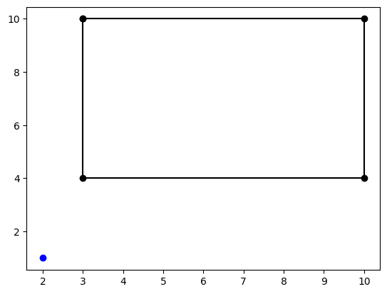

```python
# IMPORTANTE: execute o bloco acima antes de executar este!

def getCoordenadas(ret):
  ptSupDir = Ponto()
  ptInfEsq = Ponto()

  # Gera os outros dois pontos dos vértices do Retângulo
  ptSupDir.x = ret.ptInfDir.x
  ptSupDir.y = ret.ptSupEsq.y
  ptInfEsq.x = ret.ptSupEsq.x
  ptInfEsq.y = ret.ptInfDir.y

  # Gera um vetor contendo os 4 pontos do Retângulo (2 originais e 2 virtuais)
  pts = [ ret.ptSupEsq , ptSupDir , ret.ptInfDir , ptInfEsq , ret.ptSupEsq ]

  # Inicializa as listas de coordenadas sem elementos (vazia)
  x = []
  y = []

  # percorre a lista de pontos e adiciona as coordenadas nas devidas listas.
  for p in pts:
    x.append(p.x)
    y.append(p.y)

  # retorna um vetor contendo as duas listas.
  return [ x , y ]

# Importa o módulo de plotagem pyplot da biblioteca matplotlib.
import matplotlib.pyplot as plt

# getCoordenadas() retorna uma lista (Vetor) de 2 elementos. x recebe o primeiro elemento enquanto y recebe o segundo.
x, y = getCoordenadas(r)
print("x=", x)
print("y=", y)

pt = Ponto()
print("Vamos ver se seu ponto está dentro do retângulo?")
pt.x = float(input("Digite a coordenada X do seu ponto: "))
pt.y = float(input("Digite a coordenada Y do seu ponto: "))

plt.plot(x, y, '-o', color="black");
plt.plot(pt.x, pt.y, 'o', color="blue");
```

## 3 Arquivos em Python

Assim como em C, Python permite manipular arquivos textos e binários.

A abertura de um arquivo é feita por meio da função `open("nome do arquivo", "modo")`. Após a abertura, é possível chamar métodos (funções do objeto gerado) para escrever dados, ler dados, e fechar o arquivo ao final.

Uma das formas de trabalhar é atribuir o objeto retornado pela função `open()` à uma variável, então chamar os métodos `read()`,`readline()`, e `write()` para ler um caractere, ler uma linha, e escrever dados, respectivamente.

Ao finalizar a manipulação do arquivo, deve-se fechá-lo por meio da chamada do método `close()`. Isto é importante para que os dados escritos pelo comando write() sejam enviados em definitivo ao arquivo, e para que ele seja liberado pelo Sistema Operacional.

Segue exemplo abaixo, onde é escrito os dados de um vetor em um arquivo chamado `dados.txt`:

```python
dados = [ 10 , 20 , 30 , 15 , 1 , 0 , 5 ]

# abre o arquivo "dados.txt" em modo de escrita
arquivo = open("dados.txt", "w")
for d in dados:
  # escreve o dado d com uma quebra de linha na sequência, no arquivo.
  arquivo.write( f"{d}\n" )
  # escreve a mesma coisa no console.
  print(f"{d}")

# fecha o arquivo "dados.txt"
arquivo.close()
```

```
10
20
30
15
1
0
5
```

No menu ao lado, um ícone de uma pasta permite acessar o arquivo gerado com nome de `dados.txt`. Abra o arquivo e observe que cada elemento do vetor foi escrito em uma linha.

A seguir, tem-se um exemplo em que o arquivo `dados.txt` é aberto novamente, os dados são lidos e processados.

```python
# IMPORTANTE: execute o bloco acima antes de executar este!
arquivo = open("dados.txt", "r")
soma = 0
i = 0

# repetição é interrompida com break.
while True:
  # lê uma linha do arquivo e armazena ela como uma string.
  linha = arquivo.readline()
  # se uma string vazia foi retornada, chegou ao fim do arquivo, então encerra a repetição
  if linha == "":
    break

  # se chegou aqui, é porque não chegou no fim do arquivo.

  # Conta uma linha lida
  i+=1
  # Monta uma string a ser impressa na tela, formatando ela similar a função printf() da Linguagem C.
  impressao = f"Linha {i}: {linha}"

  # imprime a string montada na tela. OBS: ela já contém a quebra de linha (lida do arquivo), então print não deve escrever outra quebra de linha.
  print(impressao, end="")

  # é necessário converter a linha para um int (poderia ser float) para poder somar.
  soma += int(linha)

# fecha o arquivo "dados.txt"
arquivo.close()

# OBS: impressão formatada similar ao printf() da Linguagem C.
print("Soma: {0}".format(soma))
```

```
Linha 1: 10
Linha 2: 20
Linha 3: 30
Linha 4: 15
Linha 5: 1
Linha 6: 0
Linha 7: 5
Soma: 81
```

### 3.1 Estrutura `with`...`as`

Uma das formas de não necessitar chamar o método `close()` para fechar um arquivo é utilizando a estrutura `with`...`as`. Ela executa o método `close()` implicitamente ao seu final.

Segue a sintaxe desta estrutura:

```
with arquivo as variável:
  executa comandos do arquivo

# aqui, o arquivo existente na variável já está fechado.
```

Segue exemplo de uso de da estrutura:

```python
class Pessoa:
  nome = ""
  idade = 0
  altura = 0.0

p = Pessoa()
p.nome = "Fulano de Tal"
p.idade = 15
p.altura = 1.70

# abre o arquivo para escrita e o armazena na variável 'arquivo'.
with open("dados2.txt", "w") as arquivo:
  arquivo.write("{0}\n".format(p.nome))
  arquivo.write("{0}\n".format(p.idade))
  arquivo.write("{0}\n".format(p.altura))

# ao chegar aqui, o arquivo já fechou.

# abre ele novamente para leitura
with open("dados2.txt", "r") as arquivo:
  while True:
    linha = arquivo.readline()

    if linha == "":
      break

    print(linha, end="")

# ao chegar aqui, o arquivo já fechou novamente.
```

```
Fulano de Tal
15
1.7
```

### 3.2 Arquivos CSV

Um CSV (Comma-Separated Values) é um arquivo de texto onde cada linha representa um registro, e os campos são separados por vírgulas (ou outro delimitador, como ponto e vírgula).

Exemplo de conteúdo de um CSV:

```
nome,idade,email
João,25,joao@email.com
Maria,30,maria@email.com
```

Ao abrir este arquivo em um editor de planilhas eletrônicas como Google Planilhas, Excel, LibreOffice Calc, uma planilha como abaixo pode ser visualizada:

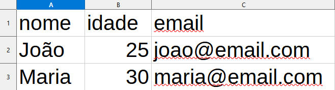

Para manipular arquivos CSV lendo e escrevendo dados de maneira simplificada, Python conta com o módulo `csv` que deve ser importado para poder ser utilizado.

O exemplo abaixo apresenta um código Python que escreve o arquivo `dados.csv` contendo os dados exemplificados acima.

```python
# importa o módulo csv
import csv

ARQUIVO = 'dados.csv'

# cria uma matriz com as strings a serem escritas no arquivo CSV.
dados = [
    ['nome', 'idade', 'email'],
    ['João', '25', 'joao@email.com'],
    ['Maria', '30', 'maria@email.com']
]

print('Dados da matriz a ser gravada no arquivo CSV:', dados, sep='\n', end='\n\n')
print(f'Escrevendo arquivo {ARQUIVO}... ', end='')
# abre o arquivo em modo de escrita, com codificação UTF-8
with open(ARQUIVO, mode='w', newline='', encoding='utf-8') as csvfile:
    # Carrega um escritor de arquivo CSV que irá escrever no arquivo aberto.
    escritor = csv.writer(csvfile, delimiter=',')
    # escreve a matriz de dados no arquivo CSV.
    escritor.writerows(dados)

# fechar o arquivo csv

print('Feito!\n')


print(f'Abrindo arquivo "{ARQUIVO}" em modo texto "simples" e imprimindo seus dados:')
# abrindo o arquivo apenas para imprimi-lo na tela.
with open(ARQUIVO, mode='r', encoding='utf-8') as arquivo:
  while True:
    line = arquivo.readline()
    if line == '':
      break;
    print(line, end='')

# fecha o arquivo csv
```

```
Dados da matriz a ser gravada no arquivo CSV:
[['nome', 'idade', 'email'], ['João', '25', 'joao@email.com'], ['Maria', '30', 'maria@email.com']]

Escrevendo arquivo dados.csv... Feito!

Abrindo arquivo "dados.csv" em modo texto "simples" e imprimindo seus dados:
nome,idade,email
João,25,joao@email.com
Maria,30,maria@email.com
```

Abra o arquivo `dados.csv` presente no menu *Arquivos*. Observe que ele foi aberto em forma de planilha.

A seguir, um código Python para ler os dados do arquivo de forma estruturada:

```python
# IMPORTANTE: execute o bloco acima antes de executar este!

# importa o módulo csv
import csv

# abre o arquivo em modo de leitura, com codificação UTF-8
with open('dados.csv', newline='', encoding='utf-8') as csvfile:
  # Carrega um leitor de arquivo CSV que irá ler do arquivo aberto.
  spamreader = csv.reader(csvfile, delimiter=',')

  # Repassa todos os dados lidos para uma matriz de dados
  matriz = [d for d in spamreader]

# fecha o arquivo csv.

print('Imprimindo os dados do arquivo de forma estruturada:')
for l in matriz:
  for c in l:
    print(f'{c:20}', end='')
  print('')

print('\nBuscando dados específicos na matriz, na linha 1 da matriz (linha 2 do arquivo CSV):')
print('matriz[1][0]:', matriz[1][0])
print('matriz[1][1]:', matriz[1][1])
print('matriz[1][2]:', matriz[1][2])
```

```
Imprimindo os dados do arquivo de forma estruturada:
nome                idade               email
João                25                  joao@email.com
Maria               30                  maria@email.com

Buscando dados específicos na matriz, na linha 1 da matriz (linha 2 do arquivo CSV):
matriz[1][0]: João
matriz[1][1]: 25
matriz[1][2]: joao@email.com
```

## 4 Strings e suas Operações

*por Iuri Sônego Cardoso com auxílio de IA.*

Strings são sequências de caracteres utilizadas para representar textos. Em Python, elas podem ser definidas utilizando apóstrofos (`'texto'`), aspas (`"texto"`), podendo estas serem simples ou triplas (`'''texto'''` ou `"""texto"""`). Estas últimas são úteis para representar textos de múltiplas linhas, conforme exemplo abaixo:

```python
nome = "João"
frase = 'Olá, mundo!'
mensagem = """Esta é uma
string de múltiplas linhas."""

print(f"nome: {nome}")
print(f"frase: {frase}")
print(f"mensagem: {mensagem}")
```

```
nome: João
frase: Olá, mundo!
mensagem: Esta é uma
string de múltiplas linhas.
```

Diferentemente da Linguagem C e algumas outras, Strings em Python são imutáveis, ou seja, uma vez criada, não é possível alterar os caracteres de uma string diretamente. No entanto, é possível criar novas strings a partir de manipulações ou operações sobre a original.

Python oferece diversas operações e métodos (funções de objetos) que permitem manipular e analisar strings de forma prática e eficiente. A seguir estão algumas das operações mais comuns:

### 4.1 Comprimento (tamanho) da String

Calcula o número de caracteres com a função `len()`.

```python
print( len("Python") )  # 6

texto = "texto"
print( len(texto) ) # 5
```

```
6
5
```

### 4.2 Concatenação

Junta duas ou mais strings.

```python
s1 = "Olá"
s2 = "Mundo"
resultado = s1 + " " + s2 # "Olá Mundo"
print(resultado)

resultado = "Linguagem"
resultado += " de "
resultado += "Programação" # Linguagem de Programação
print(resultado)
```

```
Olá Mundo
Linguagem de Programação
```

### 4.3 Repetição

Repete a string um número determinado de vezes.

```python
eco = "Oi! " * 3  # "Oi! Oi! Oi! "
print(eco)
```

```
Oi! Oi! Oi!
```

### 4.4 Indexação

Acessa um caractere específico pelo índice (começando do zero). Índices `>= 0` contam as posições a partir da esquerda, enquanto índices negativos contam as posições a partir da direita, conforme exemplo:

```python
texto = "Python"
primeira_letra = texto[0]  # "P"
ultima_letra = texto[-1]   # "n"
print(f"primeira_letra: {primeira_letra}")
print(f"ultima_letra: {ultima_letra}")

print("\nImprimindo os caracteres em ordem:")
for i in range(len(texto)):
  print(f"{i}:", texto[i])

print("\nImprimindo os caracteres em ordem inversa:")
for i in range(-1, -1-len(texto), -1):
  print(f"{i}:", texto[i])
```

```
primeira_letra: P
ultima_letra: n

Imprimindo os caracteres em ordem:
0: P
1: y
2: t
3: h
4: o
5: n

Imprimindo os caracteres em ordem inversa:
-1: n
-2: o
-3: h
-4: t
-5: y
-6: P
```

### 4.5 Iterando uma String

Assim como vetores (listas), strings também podem ser iteradas utilizando a estrutura de repetição `for`. Cada elemento recuperado é um caractere da string buscado na ordem do começo para o fim.

```python
texto = "Python"

for c in texto:
  print(c)
```

```
P
y
t
h
o
n
```

### 4.6 *Substring* (Fatiamento)

Extrai uma parte da string, também chamada de substring.

```python
mensagem = "Programação"
parte = mensagem[0:5]  # "Progr"
print(parte)

palindromo = mensagem[::-1] # oãçamargorP
print(palindromo)

parte = mensagem[0:5:1]  # "Progr"
print(parte)

# Extrai uma substring do começo ao fim, de 2 em 2 caracteres.
string = "0123456789"
parte = string[::2]  # "02468"
print(parte)

# Extrai uma substring do 2º caractere até o fim, de 2 em 2 caracteres.
parte = string[1::2]  # "13579"
print(parte)

# Extrai uma substring do último caractere até o começo, de 2 em 2 caracteres.
parte = string[::-2]  # "97531"
print(parte)
```

```
Progr
oãçamargorP
Progr
02468
13579
97531
```

### 4.7 Busca de substrings

Verifica se uma sequência de caracteres está presente em outra.

```python
print( "grama" in "Programação" )  # True
print( "Python" in "Programação" )  # False
```

```
True
False
```

### 4.8 Métodos de manipulação

Strings possuem diversos métodos úteis:

- `lower()`: Converte para minúsculas.
- `upper()`: Converte para maiúsculas.
- `strip()`: Remove espaços em branco do início e fim.
- `replace(a, b)`: Substitui todas as ocorrências da substring `a` pela substring `b`.
- `find(substr, pos=0 )`: Retorna o índice da primeira ocorrência da substring `substr` a partir da posição `pos` (quando omitido, `pos=0`).
- `split()`: Divide a string em partes, criando uma lista.
- `join()`: Junta elementos de uma lista em uma única string.

```python
texto = " Aprender Python é divertido! "
limpo = texto.strip()       # "Aprender Python é divertido!"
maiusculas = texto.upper()  #  " APRENDER PYTHON É DIVERTIDO! "
minusculas = texto.lower() # ' aprender python é divertido! '
novotexto = texto.strip().upper().replace("DIVERTIDO", "IMPORTANTE") # 'APRENDER PYTHON É IMPORTANTE!'
palavras = texto.split()    # ['Aprender', 'Python', 'é', 'divertido!']

frase = "Dizem que Python é melhor que C, mas Python é melhor que isto: é facil."
indice = frase.find("Python") # 10
indice2 = frase.find("Python", indice+1) #37
indice3 = frase.find("Python", indice2+1) # -1 (não encontrou)

print(f"O texto se manteve inalterado: '{texto}'")
print(f"limpo: '{limpo}'")
print(f"maiúsculas: '{maiusculas}'")
print(f"minúsculas: '{minusculas}'")
print(f"novotexto: '{novotexto}'")
print(f"palavras: {palavras}")
print(f"frase: {frase}")
print(f"A palavra 'Python' está presente nas posições {indice} e {indice2} da frase.")
print(f"Posição da terceira ocorrência: {indice3}")
```

```
O texto se manteve inalterado: ' Aprender Python é divertido! '
limpo: 'Aprender Python é divertido!'
maiúsculas: ' APRENDER PYTHON É DIVERTIDO! '
minúsculas: ' aprender python é divertido! '
novotexto: 'APRENDER PYTHON É IMPORTANTE!'
palavras: ['Aprender', 'Python', 'é', 'divertido!']
frase: Dizem que Python é melhor que C, mas Python é melhor que isto: é facil.
A palavra 'Python' está presente nas posições 10 e 37 da frase.
Posição da terceira ocorrência: -1
```